# basic usage

Aviezer Lifshitz

2024-05-15

Basic usage of the package.

## Basic usage

First, let’s create 5 clusters normally distributed around 1 to 5, with sd of 0.3:

```r
data <- simulate_data(n = 100, sd = 0.3, nclust = 5, dims = 2)
data
```

```
##      id        V1        V2 true_clust
## 1     1 1.0667265 1.2974904          1
## 2     2 1.5669030 1.0507419          1
## 3     3 0.9216493 0.9818881          1
## 4     4 1.1005807 1.0826089          1
## 5     5 1.3043060 0.7386772          1
## 6     6 0.5905979 1.2199023          1
## 7     7 0.5640716 1.2009019          1
## 8     8 0.8026433 1.0143766          1
## 9     9 1.0162398 1.7195164          1
## 10   10 0.5520354 1.0998368          1
## 11   11 1.1953140 1.3663256          1
## 12   12 1.5992284 1.3281665          1
## 13   13 1.2955390 1.1698961          1
## 14   14 1.1234638 0.9912329          1
```

[output cut: 486 more lines]

This is how our data looks like:

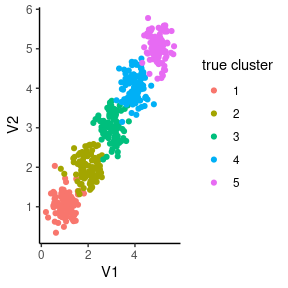

```r
data %>% ggplot(aes(x = V1, y = V2, color = factor(true_clust))) +
    geom_point() +
    scale_color_discrete(name = "true cluster")
```

Now we can cluster it using kmeans++:

```r
rownames(data) <- data$id
data_for_clust <- data %>% select(starts_with("V"))
km <- TGL_kmeans_tidy(data_for_clust,
    k = 5,
    metric = "euclid",
    verbose = TRUE
)
```

```
## will generate seeds
## generating seeds
## at seed 0
## add new core from 43 to 0
## at seed 1
## done update min distance
## seed range 350 450
## picked up 448 dist was 2.84921
## add new core from 448 to 1
## at seed 2
## done update min distance
## seed range 300 400
## picked up 222 dist was 1.3774
## add new core from 222 to 2
## at seed 3
## done update min distance
## seed range 250 350
## picked up 333 dist was 0.672893
## add new core from 333 to 3
## at seed 4
## done update min distance
## seed range 200 300
## picked up 108 dist was 0.571462
## add new core from 108 to 4
## reassign after init
## iter 0
## iter 1 changed 2
## iter 1
## iter 2 changed 0
```

The returned list contains 3 fields:

```r
names(km)
```

```
## [1] "centers" "cluster" "size"
```

`km$centers` contains a tibble with `clust` column and the cluster centers:

```r
km$centers
```

```
## # A tibble: 5 × 3
##   clust    V1    V2
##   <int> <dbl> <dbl>
## 1     1  2.03  1.98
## 2     2  4.01  4.04
## 3     3  3.04  3.04
## 4     4  1.00  1.06
## 5     5  4.98  5.02
```

clusters are numbered according to `order_func` (see ‘Custom cluster ordering’ section).

`km$cluster` contains tibble with `id` column with the observation id (`1:n` if no id column was supplied), and `clust` column with the observation assigned cluster:

```r
km$cluster
```

```
## # A tibble: 500 × 2
##    id    clust
##    <chr> <int>
##  1 1         4
##  2 2         4
##  3 3         4
##  4 4         4
##  5 5         4
##  6 6         4
##  7 7         4
##  8 8         4
##  9 9         4
## 10 10        4
## # ℹ 490 more rows
```

`km$size` contains tibble with `clust` column and `n` column with the number of points in each cluster:

```r
km$size
```

```
## # A tibble: 5 × 2
##   clust     n
##   <int> <int>
## 1     1   101
## 2     2   100
## 3     3    99
## 4     4   101
## 5     5    99
```

We can now check our clustering performance - fraction of observations that were classified correctly (Note that `match_clusters` function is internal to the package and is used only in this vignette):

```r
d <- tglkmeans:::match_clusters(data, km, 5)
sum(d$true_clust == d$new_clust, na.rm = TRUE) / sum(!is.na(d$new_clust))
```

```
## [1] 0.97
```

And plot the results:

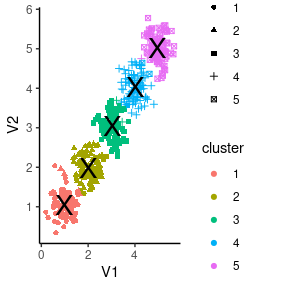

```r
d %>% ggplot(aes(x = V1, y = V2, color = factor(new_clust), shape = factor(true_clust))) +
    geom_point() +
    scale_color_discrete(name = "cluster") +
    scale_shape_discrete(name = "true cluster") +
    geom_point(data = km$centers, size = 7, color = "black", shape = "X")
```

## Custom cluster ordering

By default, the clusters where ordered using the following function: `hclust(dist(cor(t(centers))))` - hclust of the euclidean distance of the correlation matrix of the centers.

We can supply our own function to order the clusters using `reorder_func` argument. The function would be applied to each center and he clusters would be ordered by the result.

```r
km <- TGL_kmeans_tidy(data %>% select(id, starts_with("V")),
    k = 5,
    metric = "euclid",
    verbose = FALSE,
    reorder_func = median
)
km$centers
```

```
## # A tibble: 5 × 4
##   clust    id    V1    V2
##   <int> <dbl> <dbl> <dbl>
## 1     1  51.5  1.04  1.06
## 2     2 153    2.02  2.02
## 3     3 254.   3.06  3.05
## 4     4 353    4.01  4.05
## 5     5 452.   4.98  5.02
```

## Missing data

tglkmeans can deal with missing data, as long as at least one dimension is not missing. for example:

```r
data$V1[sample(1:nrow(data), round(nrow(data) * 0.2))] <- NA
data
```

```
##      id        V1        V2 true_clust
## 1     1 1.0667265 1.2974904          1
## 2     2 1.5669030 1.0507419          1
## 3     3 0.9216493 0.9818881          1
## 4     4 1.1005807 1.0826089          1
## 5     5 1.3043060 0.7386772          1
## 6     6        NA 1.2199023          1
## 7     7 0.5640716 1.2009019          1
## 8     8 0.8026433 1.0143766          1
## 9     9        NA 1.7195164          1
## 10   10 0.5520354 1.0998368          1
## 11   11 1.1953140 1.3663256          1
## 12   12 1.5992284 1.3281665          1
## 13   13        NA 1.1698961          1
## 14   14 1.1234638 0.9912329          1
```

[output cut: 486 more lines]

```r
km <- TGL_kmeans_tidy(data %>% select(id, starts_with("V")),
    k = 5,
    metric = "euclid",
    verbose = FALSE
)
d <- tglkmeans:::match_clusters(data, km, 5)
sum(d$true_clust == d$new_clust, na.rm = TRUE) / sum(!is.na(d$new_clust))
```

```
## [1] 0.98
```

and plotting the results (without the NA’s) we get:

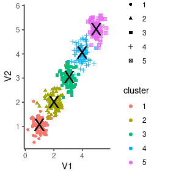

```r
d %>% ggplot(aes(x = V1, y = V2, color = factor(new_clust), shape = factor(true_clust))) +
    geom_point() +
    scale_color_discrete(name = "cluster") +
    scale_shape_discrete(name = "true cluster") +
    geom_point(data = km$centers, size = 7, color = "black", shape = "X")
```

## High dimensions

```r
data <- simulate_data(n = 100, sd = 0.3, nclust = 30, dims = 300)
km <- TGL_kmeans_tidy(data %>% select(id, starts_with("V")),
    k = 30,
    metric = "euclid",
    verbose = FALSE,
    id_column = TRUE
)
```

Note that here we supplied `id_column = TRUE` to indicate that the first column is the id column.

```r
d <- tglkmeans:::match_clusters(data, km, 30)
sum(d$true_clust == d$new_clust, na.rm = TRUE) / sum(!is.na(d$new_clust))
```

```
## [1] 1
```

## Comparison with R vanilla kmeans

Let’s compare it to R vanilla kmeans:

```r
km_standard <- kmeans(data %>% select(starts_with("V")), 30)
km_standard$clust <- tibble(id = 1:nrow(data), clust = km_standard$cluster)

d <- tglkmeans:::match_clusters(data, km_standard, 30)
sum(d$true_clust == d$new_clust, na.rm = TRUE) / sum(!is.na(d$new_clust))
```

```
## [1] 0.7142857
```

We can see that kmeans++ clusters significantly better than R vanilla kmeans.

## Random seed

we can set the seed for reproducible results:

```r
km1 <- TGL_kmeans_tidy(data %>% select(starts_with("V")),
    k = 30,
    metric = "euclid",
    verbose = FALSE,
    seed = 60427
)
km2 <- TGL_kmeans_tidy(data %>% select(starts_with("V")),
    k = 30,
    metric = "euclid",
    verbose = FALSE,
    seed = 60427
)
all(km1$centers[, -1] == km2$centers[, -1])
```

```
## [1] TRUE
```